# Convert Lat-Lon Coordinates to Polar Stereo

g. Cutter and D. Kinzey

11/8/2020

> notebook filename | reproject_epsg3412_to_4326.Rmd  
> history | Nov 2020: Converted to Rmd notebook, added ERRDAP lat-lon coordinate retrieval, J. Sevadjian. Feb 2020: Created code snippet, simplified from: AMLR_GIS_in_R by RG. Cutter and D. Kinzey. Nov 2017: AMLR_GIS_in_R.R, G Cutter.

This R code demonstrates converting latitude longitude coordinates to projected coordinates. We will access a dataset with coordinates of WGS84 lat, lon (EPSG:4326) and convert the coordinates to NSIDC Sea Ice Polar Stereographic South (EPSG: 3412).

## Install required packages and load libraries

The required packages are **maptools**, **rgdal**, and **sp**. mapdata is for coast/basemap for ggplot

```r
# Function to check if pkgs are installed, install missing pkgs, and load
pkgTest <- function(x)
{
  if (!require(x,character.only = TRUE))
  {
    install.packages(x,dep=TRUE,repos='http://cran.us.r-project.org')
    if(!require(x,character.only = TRUE)) stop(x, " :Package not found")
  }
}

list.of.packages <- c("maptools","rgdal","sp", "oce","ocedata", "mapdata", "ggplot2", "RColorBrewer", "ggspatial", "ncdf4", "lubridate","scales")

# create list of installed packages
pkges = installed.packages()[,"Package"]
for (pk in list.of.packages) {
  pkgTest(pk)
}
```

## Get a list of lat/lon coordinates from a dataset on the PolarWatch ERDDAP server

We will use the BGC Argo float in-situ dataset as our dataset. This dataset has latitude longitude coordinates.

- Request and download the coordinate variables from ERDDAP
- The request url was generated using the dataset data access form online at https://polarwatch.noaa.gov/erddap/tabledap/SOCCOM_BGC_Argo_Snapshot_Archive.html
- There are many additional file format options with ERDDAP, here we demonstrate working with csv output.

```r
url <- 'https://polarwatch.noaa.gov/erddap/tabledap/SOCCOM_BGC_Argo_Snapshot_Archive.csv0?latitude%2Clongitude&time%3E=2020-08-23T00%3A00%3A00Z&time%3C=2020-08-30T02%3A34%3A00Z'

url2 <- 'https://polarwatch.noaa.gov/erddap/tabledap/SOCCOM_BGC_Argo_Snapshot_Archive.csv0?latitude%2Clongitude&time%3E=2020-08-23T00%3A00%3A00Z&time%3C=2020-08-30T02%3A34%3A00Z&latitude%3C=-50'
download.file(url2, destfile='lat_lon_coordinates_input2.csv')
```

## Read in the Argo floats coordinates from the .csv file

- Read in the .csv file from our working directory
- Create a dataframe of coordinate points
- Coordinates are locations of individual Argo float profiles

```r
infn = "lat_lon_coordinates_input2.csv"

indata = read.csv( infn, header=FALSE)
```

## Create Spatial Dataframe

Convert the Argo float coordinate points dataframe to a spatial object (spatial dataframe)

```r
latitude <- indata$V1
longitude <- indata$V2

# Longitude for this dataset goes from 0-360 but the transform library uses -180/180
# Convert from 360 to -180/180
lon180 <- ((longitude + 180) %% 360) - 180
indata$V2 <- lon180

dfcoords = cbind(lon180,latitude)      # coords in lon, lat order
sppoints = SpatialPoints(coords = indata)
spdf     = SpatialPointsDataFrame(coords = dfcoords, indata)

# Verify initial coordinates of spatial dataframe
coordsinit <- spdf@coords
```

## Reproject data from EPSG:4326 to EPSG:3412

```r
# Define coordinate reference systems
crslonglat       = CRSargs(CRS("+init=epsg:4326")) # order is longitude latitude in R CRS
crsseaicepolster3412 = CRSargs(CRS("+init=epsg:3412"))

# Set initial CRS of spatial dataframe
proj4string(spdf) = CRS(crslonglat)
lat_lon_bbox       = spdf@bbox
print(lat_lon_bbox)
```

```
##               min     max
## lon180   -179.641 144.139
## latitude  -62.440 -51.006
```

```r
# Check the CRS
crs_set = proj4string(spdf)

# Converts from existing lat-lon crs to polar stereo (3412)
spdfProjected = spTransform(spdf, CRS(crsseaicepolster3412))
crs_projected = proj4string(spdfProjected)

coordsproj = spdfProjected@coords
bbox       = spdfProjected@bbox
print( bbox )
```

```
##               min     max
## lon180   -4385774 3967157
## latitude -3924592 2478354
```

##Make a few different maps of the data *The first and second maps use the lat/lon coordinates, the third map uses the transformed coordinates created in the previous section

### Map 1. Map Argo Float Locations on Polar Stereographic Map

- This method uses latitude and longitude and the desired crs
- oce does the projection for this map

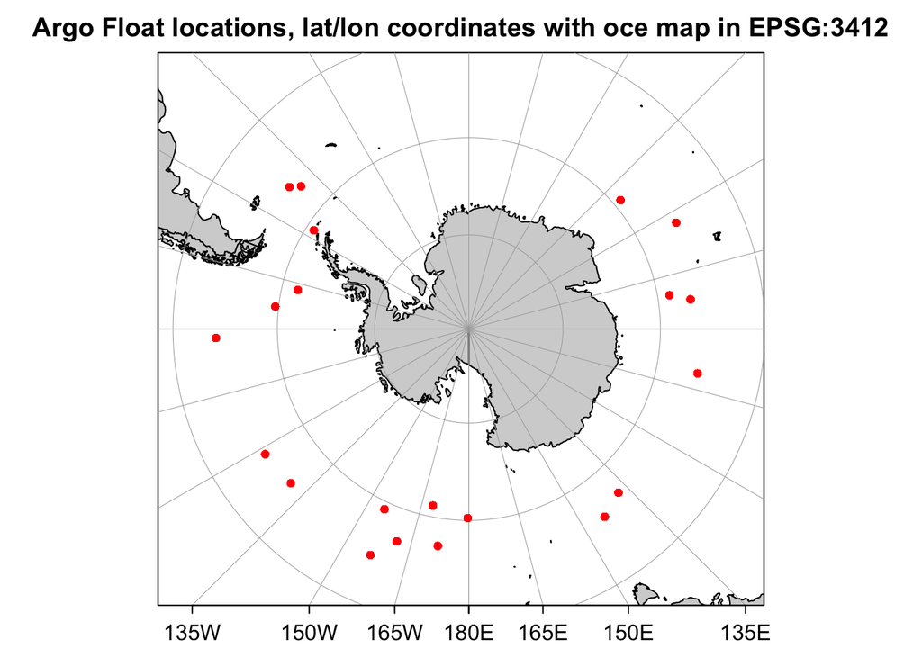

```r
# define map extents
ylim <- c(-79,-50)
xlim <- c(-170,70)
data("coastlineWorldMedium") # included in ocedata

# set plot margins (bottom, left, top, right)
par(mar=c(2, 6, 2, 6))

## make a base
mapPlot(coastlineWorldMedium,
        projection=crsseaicepolster3412,
        col="lightgray",
        longitudelim=xlim,
        latitudelim=ylim,
        main="Argo Float locations, lat/lon coordinates with oce map in EPSG:3412"
        )

## add points
mapPoints(lon180, latitude, col = "red", pch = 20)
```

### Map 2. Map Float Locations as lat lon with ggplot

- This method uses only lat/lon cordinates

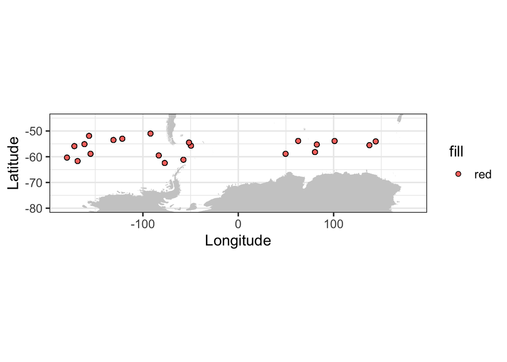

```r
xlim <- c(-180,180)
ylim <- c(-80,-45)
coast <- map_data("worldHires", ylim = ylim, xlim = xlim)
main="Argo Float locations, lat/lon coordinates with ggplot"
myplot<-ggplot(data = indata, aes(x = indata$V2, y = indata$V1, fill="red")) +
  geom_polygon(data = coast, aes(x=long, y = lat, group = group), fill = "grey80") +
  theme_bw(base_size = 15) + ylab("Latitude") + xlab("Longitude") +
  coord_fixed(2.7,xlim = xlim, ylim = ylim) +
  geom_point(data=indata, aes(x=indata$V2,y=indata$V1),size=2,shape=21,color="black")

myplot
```

### Map 3. Plot the transformed EPSG:3412 coordinate points against a dataset that we know is EPSG:3412 *Get NSIDC CDR gridded data from PolarWatch ERDDDAP* Then plot it with the transformed points on top using ggplot

```r
# First get the lat/lon grid of the NSIDC dataset
# NetCDF gridded data

url <- 'https://polarwatch.noaa.gov/erddap/griddap/'
grid_id <- 'nsidcCDRice_sh_grid'
grid_urlcall <- paste0(url,grid_id,'.nc?latitude[(4337500.0):1:(-3937500.0)][(-3937500.0):1:(3937500.0)],longitude[(4337500.0):1:(-3937500.0)][(-3937500.0):1:(3937500.0)]')
grid_nc <- download.file(grid_urlcall,destfile="grid.nc",mode='wb')

# Read the lat/lon grid file
gridFid <- nc_open('grid.nc')
ygrid <- ncvar_get(gridFid, varid="ygrid")
xgrid <- ncvar_get(gridFid, varid="xgrid")
longitude <- ncvar_get(gridFid, varid="longitude")
latitude <- ncvar_get(gridFid, varid="latitude")
nc_close(gridFid)

# Get projected sea ice data
# request and read in corresponding ice data

inds = which(latitude < 0, arr.ind=TRUE)
rowrange <- range(inds[,1])
colrange <- range(inds[,2])

dataid <- 'nsidcCDRiceSQshmday'
varnames <- c('seaice_conc_monthly_cdr')
datestring <- '[(2017-11-01T00:00:00Z):1:(2017-12-30T00:00:00Z)]'
coordstring <- paste0('[',colrange[1],':1:',colrange[2]-1,'][',rowrange[1],':1:',rowrange[2]-1,']')

for (i in 1:length(varnames)) {
   if (i == 1) {
     urlcall <- paste0(url,dataid,'.nc?',varnames[i],datestring,coordstring)
     }
   else {
     urlcall <- paste0(urlcall,',',varnames[i],datestring,coordstring)
     }
}

#Download the sea ice data NetCDF file  (two months of data)
data_nc <- download.file(urlcall,destfile="data.nc",mode='wb')
dataFid <- nc_open('data.nc')

datatime <- ncvar_get(dataFid, varid="time")
datatime <- as.Date(as.POSIXlt(datatime,origin='1970-01-01',tz= "GMT"))

ygrid <- ncvar_get(dataFid, varid="ygrid")
xgrid <- ncvar_get(dataFid, varid="xgrid")

seaiceCDR <- ncvar_get(dataFid, varid=varnames[1])

nc_close(dataFid)

urlcall <- paste0(url,grid_id,'.nc?longitude',coordstring,',latitude',coordstring)
grid_subset <- download.file(urlcall,destfile="grid_subset.nc",mode='wb')

# Read and format the subsetted grid data from the netCDF file
gridSubsetFid <- nc_open('grid_subset.nc')
ygrid <- ncvar_get(gridSubsetFid, varid="ygrid")
xgrid <- ncvar_get(gridSubsetFid, varid="xgrid")
longitudeSubset <- ncvar_get(gridSubsetFid, varid="longitude")
latitudeSubset <- ncvar_get(gridSubsetFid, varid="latitude")

nc_close(gridSubsetFid)
```

## Plot the projected point data on top of the NSIDC sea ice data

*Visually check the locations of the transformed coordinates

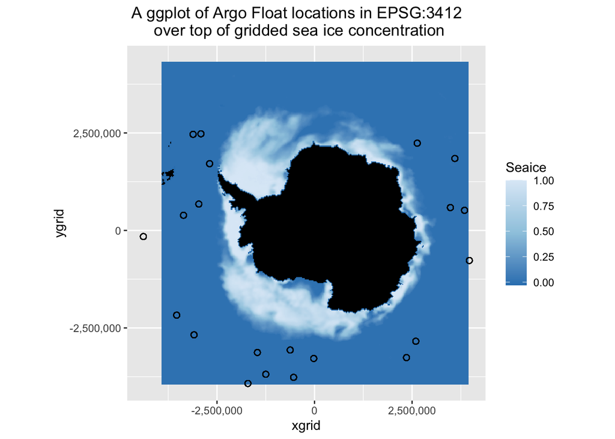

```r
plotdate <- '2017-12-16'
idate = which((month(datatime)==month(plotdate)) & (year(datatime)==year(plotdate)))
dims <- dim(longitude)
icemap.df <- data.frame(Longitude=array(longitudeSubset,dims[1]*dims[2]),
                        Latitude=array(latitudeSubset,dims[1]*dims[2]))
icemap.df$Seaice <- array(seaiceCDR[,,idate],dims[1]*dims[2])
dims <- dim(xgrid)
icemap2 <- expand.grid(xgrid=xgrid,ygrid=ygrid)
icemap2$Seaice <- array(seaiceCDR[,,idate],dim(xgrid)*dim(ygrid))
icemap2$Seaice[icemap2$Seaice > 2] <- NA

df_projected <- as.data.frame(spdfProjected)


main=" A ggplot of Argo Float locations in EPSG:3412\n      over top of gridded sea ice concentration"
myplot <- ggplot(data = icemap2, aes(x = xgrid, y = ygrid, fill=Seaice) ) +
       geom_tile() +
       coord_fixed(ratio = 1) +
       scale_y_continuous(labels = comma) +
       scale_x_continuous(labels = comma) +
       scale_fill_gradientn(colours=rev(brewer.pal(n = 1, name = "Blues")),na.value="black") +
       geom_point(data=df_projected, aes(x=lon180,y=latitude),inherit.aes = FALSE, size=2,shape=21,color="black") +
       labs(title=main)
myplot
```